# Client Report - [Project 4: Can You Predict That?]

- Show All Code
- Hide All Code

Course DS 250

Author

[Samantha Powell]

## Elevator pitch: The data reveals that most homes in Denver were built before 1980, reflecting construction trends from the asbestos era. Garage type and architectural features strongly correlate with the build period, showing that attached garages and single-story designs are key indicators of homes built post-1980. Living area distributions overlap but highlight occasional outliers, offering potential for nuanced predictive modeling.

```
<class 'pandas.core.frame.DataFrame'>
RangeIndex: 22913 entries, 0 to 22912
Data columns (total 51 columns):
 #   Column                            Non-Null Count  Dtype
---  ------                            --------------  -----
 0   parcel                            22913 non-null  object
 1   abstrprd                          22913 non-null  int64
 2   livearea                          22913 non-null  int64
 3   finbsmnt                          22913 non-null  int64
 4   basement                          22913 non-null  int64
 5   yrbuilt                           22913 non-null  int64
 6   totunits                          22913 non-null  int64
 7   stories                           22913 non-null  int64
 8   nocars                            22913 non-null  int64
 9   numbdrm                           22913 non-null  int64
 10  numbaths                          22913 non-null  int64
 11  sprice                            22913 non-null  int64
 12  deduct                            22913 non-null  int64
 13  netprice                          22913 non-null  int64
 14  tasp                              22913 non-null  int64
 15  smonth                            22913 non-null  int64
 16  syear                             22913 non-null  int64
 17  condition_AVG                     22913 non-null  int64
 18  condition_Excel                   22913 non-null  int64
 19  condition_Fair                    22913 non-null  int64
 20  condition_Good                    22913 non-null  int64
 21  condition_VGood                   22913 non-null  int64
 22  quality_A                         22913 non-null  int64
 23  quality_B                         22913 non-null  int64
 24  quality_C                         22913 non-null  int64
 25  quality_D                         22913 non-null  int64
 26  quality_X                         22913 non-null  int64
 27  gartype_Att                       22913 non-null  int64
 28  gartype_Att/Det                   22913 non-null  int64
 29  gartype_CP                        22913 non-null  int64
 30  gartype_Det                       22913 non-null  int64
 31  gartype_None                      22913 non-null  int64
 32  gartype_att/CP                    22913 non-null  int64
 33  gartype_det/CP                    22913 non-null  int64
 34  arcstyle_BI-LEVEL                 22913 non-null  int64
```

[output cut: 69 more lines]

```
           status_V    before1980
count  22913.000000  22913.000000
mean       0.054074      0.624929
std        0.226169      0.484152
min        0.000000      0.000000
25%        0.000000      0.000000
50%        0.000000      1.000000
75%        0.000000      1.000000
max        1.000000      1.000000

[8 rows x 50 columns]
before1980
1    14319
0     8594
Name: count, dtype: int64
```

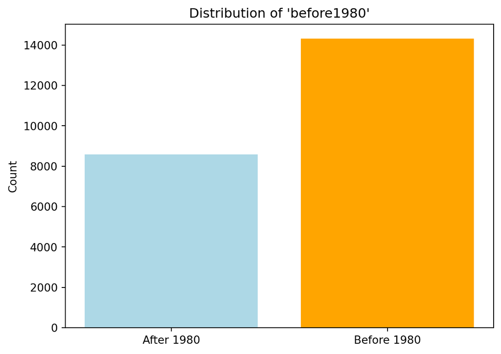

```python
import pandas as pd
import matplotlib.pyplot as plt

# Load the dataset
data = pd.read_csv('dwellings_ml.csv')

# Quick data exploration
print(data.info())  # Check for null values and data types
print(data.describe())  # Summary statistics

# Inspect the target variable
print(data['before1980'].value_counts())

# Plot the distribution of 'before1980'
labels = ['After 1980', 'Before 1980']
sizes = data['before1980'].value_counts().sort_index()
plt.bar(labels, sizes, color=['lightblue', 'orange'])
plt.title("Distribution of 'before1980'")
plt.ylabel("Count")
plt.show()
```

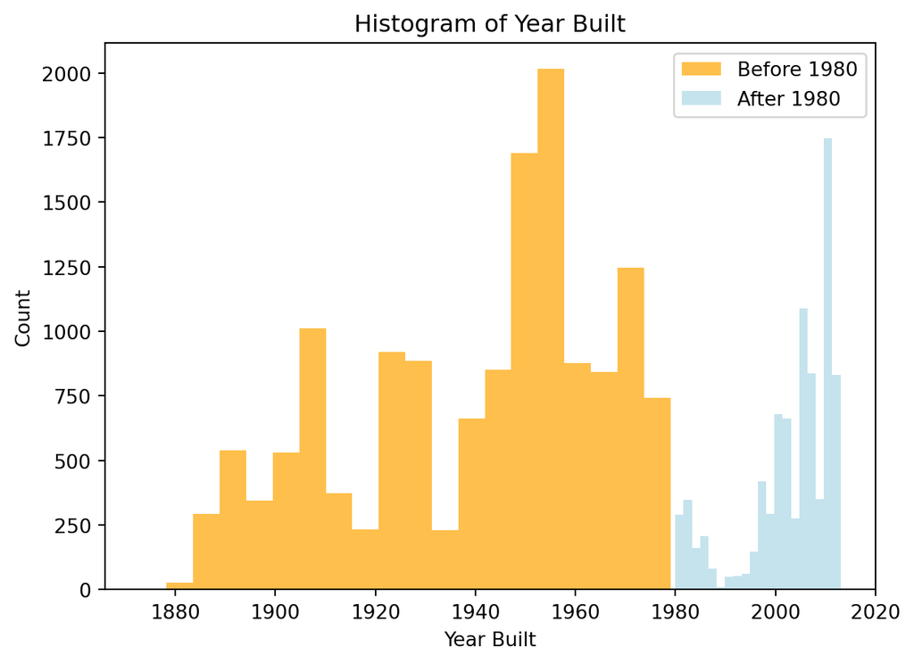

```python
import pandas as pd
import matplotlib.pyplot as plt

# Load the dataset
data = pd.read_csv('dwellings_ml.csv')

# Group data by before1980
data['yrbuilt_group'] = data['before1980'].map({1: 'Before 1980', 0: 'After 1980'})
groups = data.groupby('yrbuilt_group')['yrbuilt']

# Plot Year Built distribution by before1980
plt.hist(groups.get_group('Before 1980'), bins=20, alpha=0.7, label='Before 1980', color='orange')
plt.hist(groups.get_group('After 1980'), bins=20, alpha=0.7, label='After 1980', color='lightblue')
plt.title("Histogram of Year Built")
plt.xlabel("Year Built")
plt.ylabel("Count")
plt.legend()
plt.show()
```